# Justiça Eleitoral, Paz e Democracia

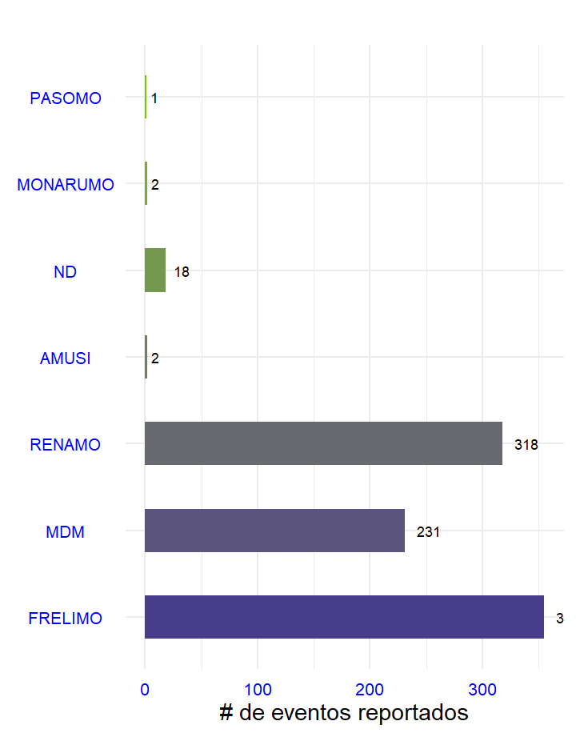

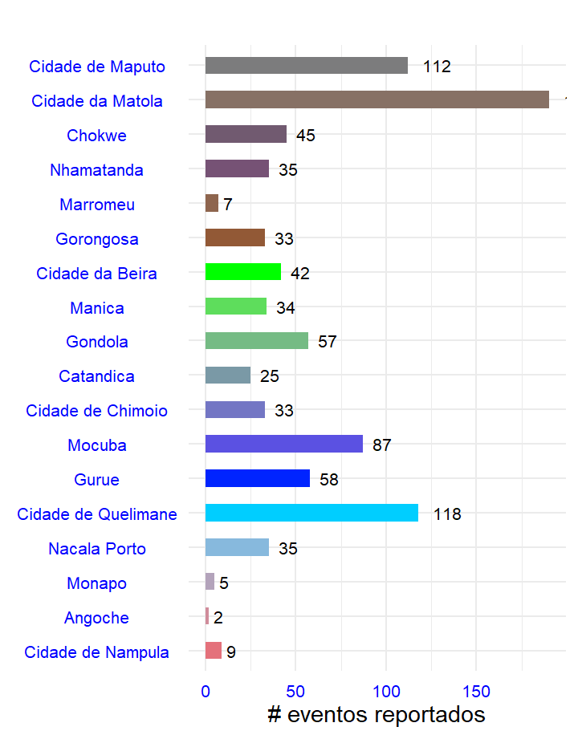

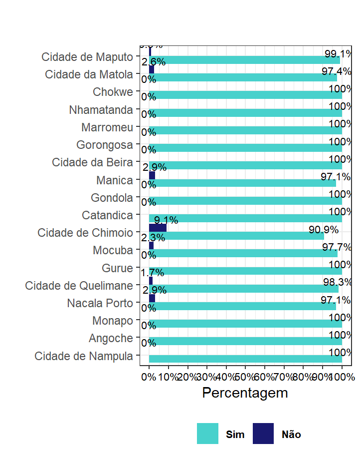

Preliminary data visualization of the events that the general election monitors will observe during the election campaign process.

All PCBG elections monitoring and electoral conflict resolution/violence tracking activity are reported through ELMO, an open-source customized data collection platform designed by The Carter Center and adapted by Counterpart for use by the Civil Society Monitoring Network in Mozambique. ELMO houses each of the questionnaires developed for electoral events and incident reporting. Monitors will submit their data by downloading questionnaires onto Android-based smartphones via another open-source platform called ODK Collect. Monitors will record their observations, including photographs and geolocation pins, for real-time data uploads to ELMO.

ELMO will be used as a primary source to combine and disaggregate data according to the CSMN monitoring methodology; this data will be used to support the CMSN findings, conclusions, reports and recommendations throughout the process. In addition, questionnaires are structured to trigger mobilization for rapid responses to violent incidents such as tracking, CRR intervention, and resolution efforts. Users at all levels will have controlled access to view the data and generate visualizations for information sharing and reporting purposes. In addition, for security purposes, CMSN will develop protocols for information sharing via WhatsApp.

# Overview da Campanha

### # of events submitted

1008

### # of political party organizing the event

8

### # incident occured

2

### **Number of events observed by each political party**

The following map displays the number of events followed by monitors as aggregated data by each political party during the rally of campaining in each geographical area selected previously by CPI and all partner´s organizations to monitore events during the campaing.

[interactive chart not shown]

# Eventos reportados

### **Eventos realizados por cada partido politico observado**

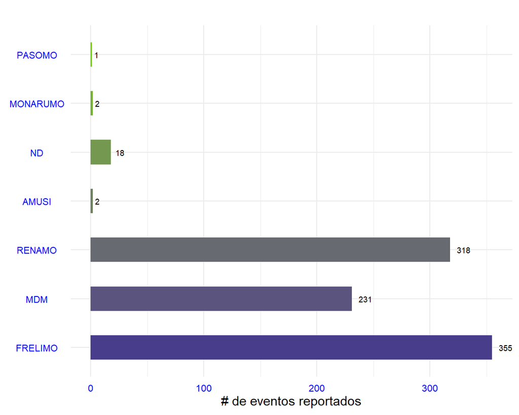

### **Número de eventos reportados nos distritos seleccionados**

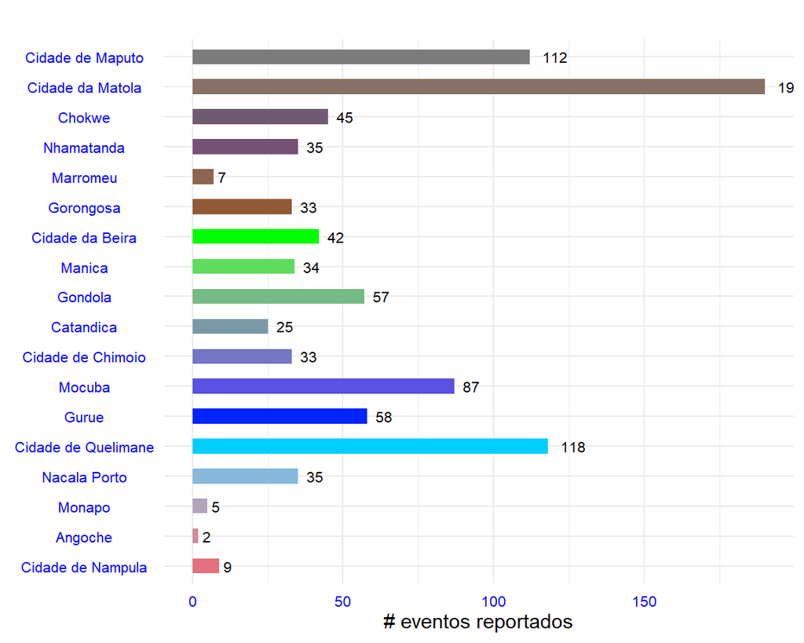

### **Atention:**

The data displayed here it´s from the events observed by the monitors in the first 4 days (*until 9 pm on 03/09/2019* ). Around 82 events had missing information regadring the corresponding districts and those were excluded for the elaboration of these presented graphs. This data need to be corrected!

# Descição de Eventos

### valiação percentual dos eventos realizados por cada partido politico

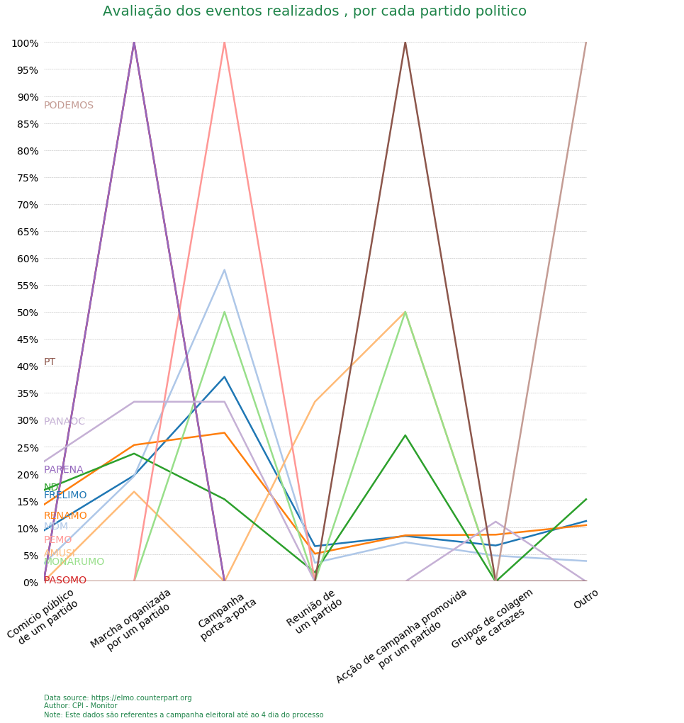

### **O ambiente onde está a decorre este evento é calmo**

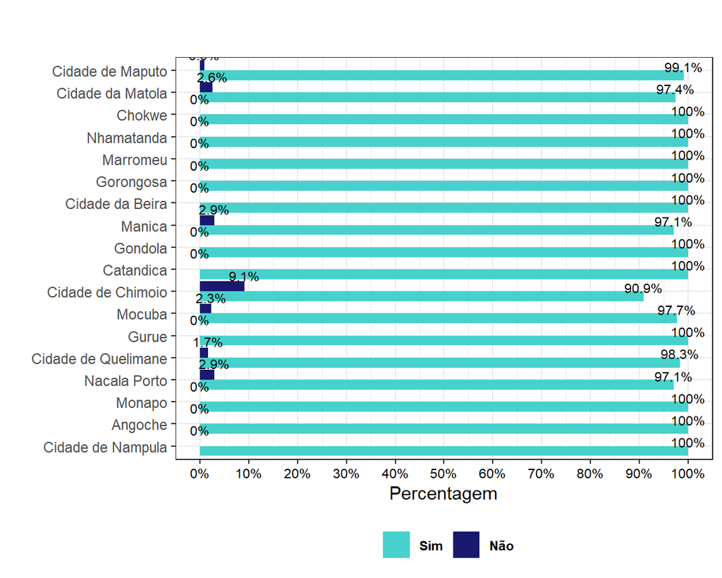

### **Número de dias decorridos de campanha**

[interactive chart not shown]